# Factor Analytic Selection Tools: FAST and iClass

`fastIC()` and `plot_fastIC()`

Author

Julian Taylor

Published

August 18, 2026

## Overview

`fastIC()` provides a unified implementation of two complementary approaches for summarising variety performance from a **Factor Analytic (FA) linear mixed model** fitted in ASReml-R V4:

- **FAST** (Factor Analytic Selection Tools; Smith & Cullis, 2018) — global Overall Performance and stability across all environments.
- **iClass** (interaction class; Smith et al., 2021) — within-class performance and stability for environments grouped by their loading sign patterns.

Both frameworks are treated as a single continuum. FAST global metrics (`GlobalOP`, `GlobalRMSD`) are always computed across **all** environments. iClass metrics (`iclass`, `iClassOP`, `iClassRMSD`) partition environments by the sign pattern of their first `ic.num` rotated loadings. When `ic.num = 1` and — as is typical after rotation — all first-factor loadings are positive, there is exactly one iClass and the two frameworks agree exactly: `iClassOP = GlobalOP` and `iClassRMSD = GlobalRMSD`.

`plot_fastIC()` provides six complementary visualisations:

| Type | Description |
| --- | --- |
| `"fast"` | Global OP vs stability (GlobalRMSD) scatter with quadrant annotations |
| `"biplot"` | FA biplot: genotype scores + environment loading arrows |
| `"CVE"` | Common Variety Effect heatmap (genotype × environment) |
| `"iclass"` | iClassOP vs iClassRMSD scatter, faceted by interaction class |
| `"OP.pairs"` | Lower-triangular pairs plot of iClassOP across all classes |
| `"OP.variety"` | iClassOP trajectory for highlighted varieties across classes |

## Mathematical Framework

### Factor Analytic mixed model

An FA($k$) random structure decomposes the $t \times t$ genetic covariance matrix as $\mathbf{G} = \hat{\boldsymbol{\Lambda}}\hat{\boldsymbol{\Lambda}}^\top + \hat{\boldsymbol{\Psi}}$, where $\hat{\boldsymbol{\Lambda}} \in \mathbb{R}^{t \times k}$ are the varimax-rotated loadings (element $\hat{\lambda}_{rj}$: factor $r$, environment $j$) and $\hat{\boldsymbol{\Psi}} = \operatorname{diag}(\hat{\psi}_1,\ldots,\hat{\psi}_t)$ is the diagonal specific-variance matrix. After rotation, factor 1 captures the dominant non-crossover GEI with typically all-positive loadings; higher factors are bipolar. `faSummary()` additionally returns score EBLUPs $\hat{\mathbf{F}} \in \mathbb{R}^{n \times k}$ (element $\hat{f}_{rg}$: factor $r$, variety $g$).

The **Common Variety Effect** for variety $g$ in environment $j$ is:

$$\widehat{\text{CVE}}(g,j) = \hat{\boldsymbol{\lambda}}_j^\top \hat{\mathbf{f}}_g
= \sum_{r=1}^{k} \hat{\lambda}_{rj}\,\hat{f}_{rg},
\qquad
\widehat{\mathbf{CVE}} = \hat{\mathbf{F}}\hat{\boldsymbol{\Lambda}}^\top \in \mathbb{R}^{n \times t}.$$

### FAST global metrics

Let $\bar{\lambda}_{1} = t^{-1}\sum_j \hat{\lambda}_{1j}$ be the mean of the first-factor loadings. The global metrics for variety $g$ are:

$$\text{GlobalOP}(g) = \bar{\lambda}_{1}\,\hat{f}_{1g}, \qquad
\text{GlobalRMSD}(g) = \sqrt{t^{-1}\sum_j \bigl(\widehat{\text{CVE}}(g,j) - \hat{\lambda}_{1j}\hat{f}_{1g}\bigr)^2}.$$

`global_op` is on the trait scale (expected performance at an average environment); `global_stab` is the RMSD of the first-factor residual — small for broadly adapted varieties, large for environment-specific responders.

### iClass metrics

Each environment is assigned a class label from the sign pattern of its first $q = \texttt{ic.num}$ loadings:

$$\text{iClass}(j) = \bigotimes_{r=1}^{q}
\begin{cases} \textup{p} & \hat{\lambda}_{rj} \ge 0 \\ \textup{n} & \hat{\lambda}_{rj} < 0 \end{cases}.$$

For class $\omega$ with environment index set $\mathbf{E}_\omega$, let $\bar{\boldsymbol{\lambda}}_\omega = |\omega|^{-1}\sum_{j\in\mathbf{E}_\omega}(\hat{\lambda}_{1j},\ldots,\hat{\lambda}_{qj})^\top$ be the class mean loading vector. Then:

$$\text{iClassOP}(g,\omega) = \sum_{r=1}^{q} \bar{\lambda}_{r\omega}\,\hat{f}_{rg}, \qquad
\text{iClassRMSD}(g,\omega) = \sqrt{|\omega|^{-1}\sum_{j\in\mathbf{E}_\omega}
\Bigl(\widehat{\text{CVE}}(g,j) - \sum_{r=1}^{q}\hat{\lambda}_{rj}\hat{f}_{rg}\Bigr)^2}.$$

`iClassRMSD` uses the residual from the first $q$ factors; the $k$th factor is reserved for this purpose, so $1 \le \texttt{ic.num} \le k-1$.

FAST is the special case $q = 1$ with one class spanning all environments: $\text{iClassOP} = \text{GlobalOP}$ and $\text{iClassRMSD} = \text{GlobalRMSD}$. When $q \ge 2$, environments split into classes and `iClassOP` captures within-class performance, revealing crossover GEI invisible to `GlobalOP`.

### Variance Accounted For (VAF)

The total genetic variance for environment $j$ is $\sigma^2_j = \sum_r \hat{\lambda}_{rj}^2 + \hat{\psi}_j$. The per-factor and specific proportions are:

$$\text{VAF}(r,j) = \frac{\hat{\lambda}_{rj}^2}{\sigma^2_j}, \qquad
\text{Specific}(j) = \frac{\hat{\psi}_j}{\sigma^2_j}, \qquad
\sum_{r=1}^{k}\text{VAF}(r,j) + \text{Specific}(j) = 1.$$

The overall VAF for factor $r$ pools across all environments: $\overline{\text{VAF}}(r) = \sum_j\hat{\lambda}_{rj}^2 \,/\, \sum_j\sigma^2_j$.

## Example 1 — Balanced MET: 50 Varieties × 12 Sites

### Data simulation

> **Requires:** ASReml-R V4. The vignette is pre-rendered so no licence is needed to read it; run the code chunks only if you have the packages installed.

```r
set.seed(101L)
sim1 <- simTrialData(
  nvar        = 50L,
  nsite       = 12L,
  nrep        = 3L,
  G           = "auto",
  incidence   = "balanced",
  seed        = 101L,
  verbose     = FALSE,
  sim.options = list(
    g_cor_min     = 0.10,
    g_cor_max     = 0.65,
    sigma_genetic = 300,
    error_sd      = 280,
    site_mean     = 4500,
    site_sd       = 450
  )
)
dat1         <- sim1$data
dat1$Site    <- factor(dat1$Site)
dat1$Variety <- factor(dat1$Variety)
dat1$Rep     <- factor(dat1$Rep)
dat1$Row     <- factor(dat1$Row)
dat1$Column  <- factor(dat1$Column)
```

A quick look at the true genetic correlation structure confirms meaningful variability — some environments are quite poorly correlated with others, providing scope for crossover interaction.

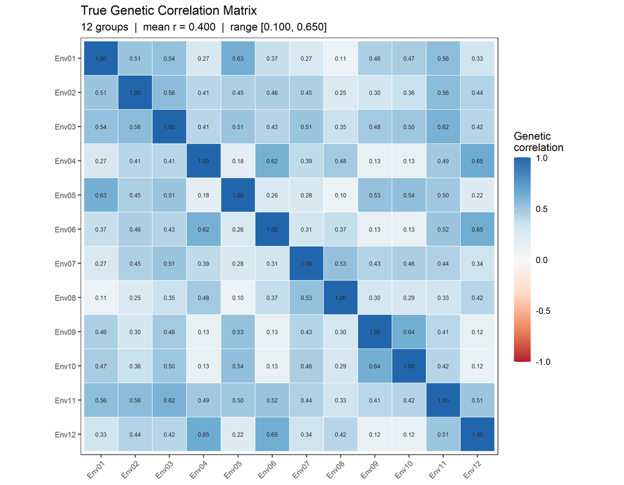

```r
plot_simTrialData(sim1, type = "correlation")
```

### Fitting FA(1), FA(2) and FA(3) models

We fit three models of increasing complexity, using `at(Site):Rep` for replicate effects within sites:

```r
m1_fa1 <- asreml(
  yield  ~ Site,
  random = ~ fa(Site, 1):Variety + at(Site):Rep,
  data   = dat1,
  maxit  = 30L
)
m1_fa1 <- update(m1_fa1)
```

```r
m1_fa2 <- asreml(
  yield  ~ Site,
  random = ~ fa(Site, 2):Variety + at(Site):Rep,
  data   = dat1,
  maxit  = 30L
)
m1_fa2 <- update(m1_fa2)
```

```r
m1_fa3 <- asreml(
  yield  ~ Site,
  random = ~ fa(Site, 3):Variety + at(Site):Rep,
  data   = dat1,
  maxit  = 30L
)
m1_fa3 <- update(m1_fa3)
```

AIC confirms that the FA(3) model provides the best fit:

```r
.aic <- function(m) -2 * m$loglik + 2 * nrow(summary(m)$varcomp)
data.frame(
  Model  = c("FA(1)", "FA(2)", "FA(3)"),
  LogLik = round(c(m1_fa1$loglik, m1_fa2$loglik, m1_fa3$loglik), 2),
  npar   = c(nrow(summary(m1_fa1)$varcomp),
             nrow(summary(m1_fa2)$varcomp),
             nrow(summary(m1_fa3)$varcomp)),
  AIC    = round(c(.aic(m1_fa1), .aic(m1_fa2), .aic(m1_fa3)), 2)
)
```

```
  Model    LogLik npar      AIC
1 FA(1) -11433.93   37 22941.86
2 FA(2) -11404.90   49 22907.80
3 FA(3) -11391.55   61 22905.10
```

### Running `fastIC()`

We run `fastIC()` on the FA(3) model with `ic.num = 2`. The first two rotated factors define the iClass labels — environments with loading sign pattern `"pp"` (positive on both factors) form one class, those with pattern `"pn"` form another. Factor 3 is reserved for iClassRMSD.

```r
res1 <- fastIC(
  model  = m1_fa3,
  term   = "fa(Site, 3):Variety",
  ic.num = 2L
)
```

```r
# iClass assignments for each site
unique(res1[, c("Site", "iclass")])[order(unique(res1[, c("Site","iclass")])$iclass), ]
```

```
     Site iclass
1   Env01     pn
51  Env02     pn
101 Env04     pn
151 Env05     pn
201 Env06     pn
251 Env11     pn
301 Env12     pn
351 Env03     pp
401 Env07     pp
451 Env08     pp
501 Env09     pp
551 Env10     pp
```

```r
cat("iClass sizes (number of environments):\n")
```

```
iClass sizes (number of environments):
```

```r
print(table(unique(res1[, c("Site","iclass")])$iclass))
```

```
pn pp
 7  5
```

The two iClasses partition sites by whether they respond positively or negatively to the second FA factor — a measure of crossover GEI that is invisible from the global rankings alone.

### Variance Accounted For

The FA variance decomposition is performed by `faSummary()`, and the `"VAF"` plot of `plot_faSummary()` visualises it. The plot below shows, for each environment, what proportion of the total genetic variance ($\sigma^2_j = \sum_r \hat{\lambda}_{rj}^2 + \hat{\psi}_j$) is accounted for by each FA factor versus left in the specific variance. Each bar reaches 100%; Factor 1 (darkest blue) occupies the bottom and typically dominates, with Factor 2 and Factor 3 adding further layers, and the specific variance (grey) at the top representing unexplained genetic variation. The dashed horizontal line marks the overall mean proportion explained across all environments.

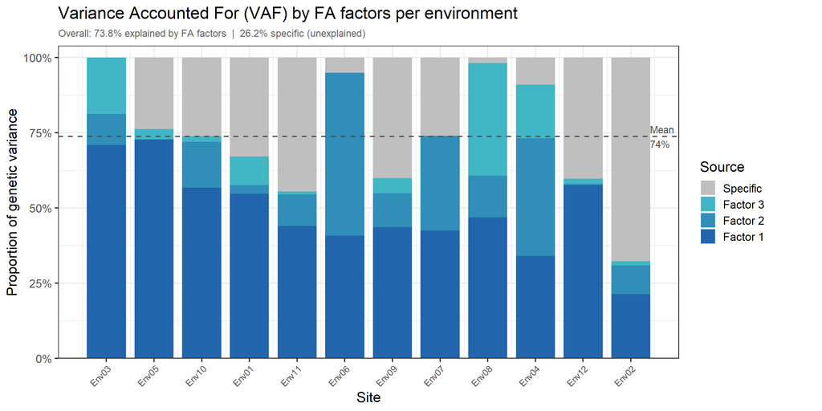

```r
fas1 <- faSummary(m1_fa3, term = "fa(Site, 3):Variety")
plot_faSummary(fas1, type = "VAF")
```

### FAST: Global OP vs Stability

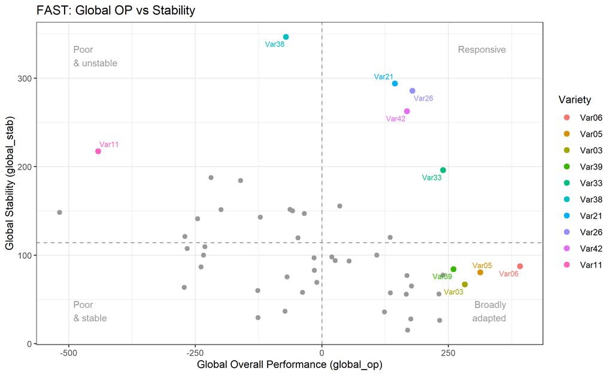

```r
plot_fastIC(res1, type = "fast", n_highlight = 5L)
```

### FA biplot

The biplot places genotypes in the space of factor scores (1 vs 2) and environments as arrows scaled by their loadings. Environments coloured by iClass visually confirm the separation: `"pp"` sites point into the positive upper-right; `"pn"` sites point into the positive-negative quadrant. Varieties closest to an environment arrow tend to perform well in that environment.

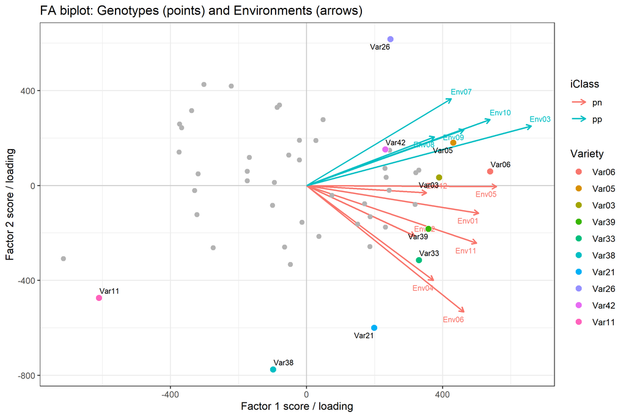

```r
plot_fastIC(res1, type = "biplot", n_highlight = 5L)
```

### CVE heatmap

The Common Variety Effect heatmap shows the full genotype × environment performance surface. Environments are grouped by iClass (column facets) and ordered by first-factor loading within each class, while varieties are ordered by `global_op` from top (best) to bottom (poorest). The diverging palette makes crossover patterns immediately visible — varieties that are strongly positive in one class but near-zero or negative in the other.

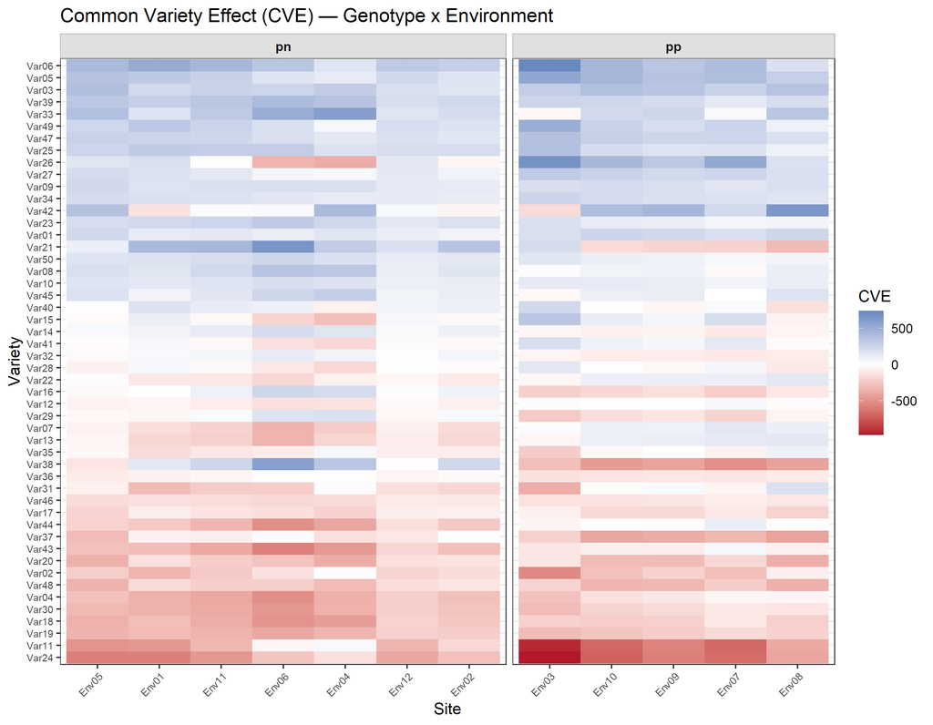

```r
plot_fastIC(res1, type = "CVE")
```

### iClass: Within-class OP vs RMSD

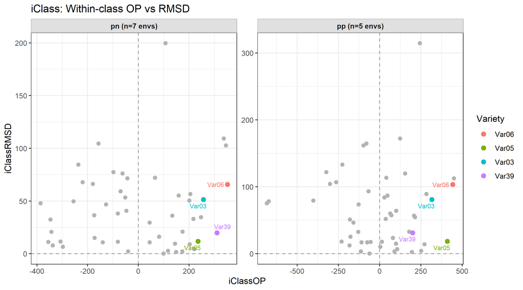

```r
plot_fastIC(res1, type = "iclass", n_highlight = 4L)
```

### iClassOP pairs plot

With two iClasses the `"OP.pairs"` plot is a single scatter of iClassOP in class `"pn"` (x-axis) against class `"pp"` (y-axis). The dashed diagonal marks equal performance across classes. Varieties well above the line are specialists for `"pp"` environments; those below favour `"pn"` environments. Points near the diagonal are generalists.

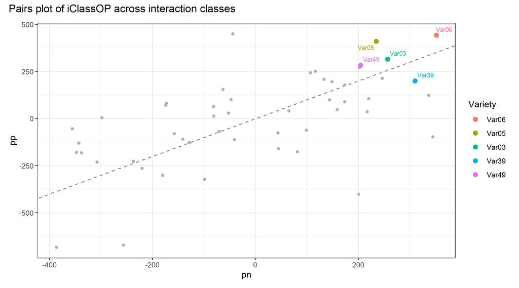

```r
plot_fastIC(res1, type = "OP.pairs", n_highlight = 5L)
```

### Variety trajectory

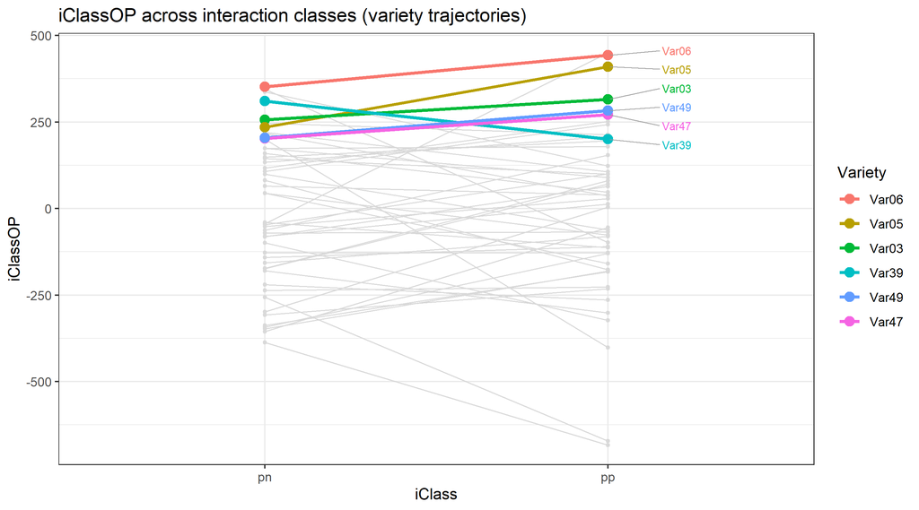

```r
plot_fastIC(res1, type = "OP.variety", n_highlight = 6L)
```

## Example 2 — Unbalanced MET: 75 Varieties × 25 Sites

### Data simulation

```r
set.seed(202L)
sim2 <- simTrialData(
  nvar        = 75L,
  nsite       = 25L,
  nrep        = 2L,
  G           = "auto",
  incidence   = "unbalanced",
  seed        = 202L,
  verbose     = FALSE,
  sim.options = list(
    g_cor_min     = 0.05,
    g_cor_max     = 0.60,
    sigma_genetic = 320,
    error_sd      = 300,
    site_mean     = 4500,
    site_sd       = 500,
    core_pct      = 0.25,
    core_min_sites_pct = 0.80,
    reg_min_sites_pct  = 0.35,
    reg_max_sites_pct  = 0.75
  )
)
dat2         <- sim2$data
dat2$Site    <- factor(dat2$Site)
dat2$Variety <- factor(dat2$Variety)
dat2$Rep     <- factor(dat2$Rep)
dat2$Row     <- factor(dat2$Row)
dat2$Column  <- factor(dat2$Column)
```

The unbalanced incidence creates a core set of varieties present across most sites and a peripheral set with sparser coverage:

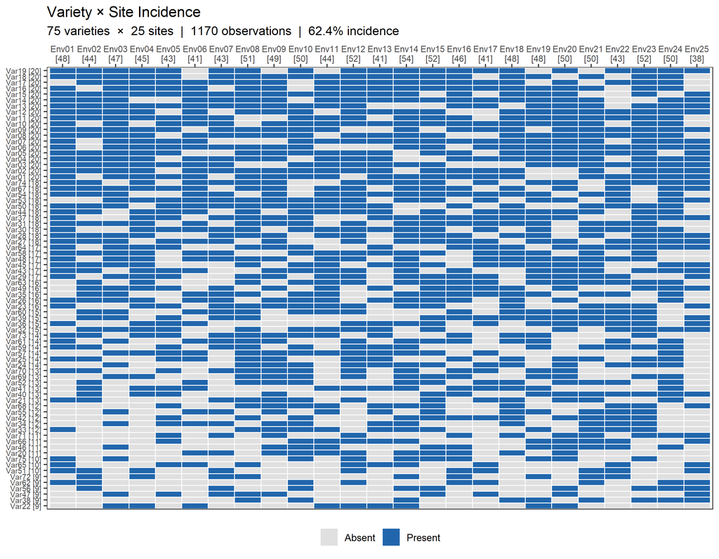

```r
plot_simTrialData(sim2, type = "incidence")
```

Connectivity summary:

```r
inc <- sim2$params$incidence
cat("Varieties per site — mean:", round(mean(colSums(inc)), 1),
    " range [", min(colSums(inc)), ",", max(colSums(inc)), "]\n")
```

```
Varieties per site — mean: 46.8  range [ 38 , 54 ]
```

```r
cat("Sites per variety  — mean:", round(mean(rowSums(inc)), 1),
    " range [", min(rowSums(inc)), ",", max(rowSums(inc)), "]\n")
```

```
Sites per variety  — mean: 15.6  range [ 9 , 20 ]
```

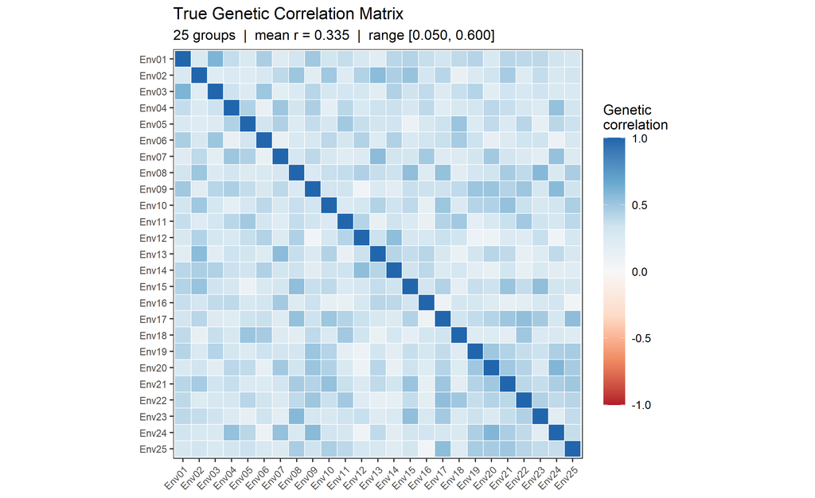

```r
plot_simTrialData(sim2, type = "correlation")
```

### Fitting FA(2), FA(3) and FA(4) models

```r
m2_fa2 <- asreml(
  yield  ~ Site,
  random = ~ fa(Site, 2):Variety + at(Site):Rep,
  data   = dat2,
  maxit  = 30L
)
m2_fa2 <- update(m2_fa2)
```

```r
m2_fa3 <- asreml(
  yield  ~ Site,
  random = ~ fa(Site, 3):Variety + at(Site):Rep,
  data   = dat2,
  maxit  = 30L
)
m2_fa3 <- update(m2_fa3)
```

```r
m2_fa4 <- asreml(
  yield  ~ Site,
  random = ~ fa(Site, 4):Variety + at(Site):Rep,
  data   = dat2,
  maxit  = 30L
)
m2_fa4 <- update(m2_fa4)
```

```r
data.frame(
  Model  = c("FA(2)", "FA(3)", "FA(4)"),
  LogLik = round(c(m2_fa2$loglik, m2_fa3$loglik, m2_fa4$loglik), 2),
  npar   = c(nrow(summary(m2_fa2)$varcomp),
             nrow(summary(m2_fa3)$varcomp),
             nrow(summary(m2_fa4)$varcomp)),
  AIC    = round(c(.aic(m2_fa2), .aic(m2_fa3), .aic(m2_fa4)), 2)
)
```

```
  Model    LogLik npar      AIC
1 FA(2) -14981.57  101 30165.13
2 FA(3) -14960.77  126 30173.54
3 FA(4) -14942.11  151 30186.23
```

### Running `fastIC()` with ic.num = 3

With a FA(4) model and `ic.num = 3`, the first three factors define up to $2^3 = 8$ potential iClasses, though only those sign patterns that are actually represented by at least one environment will appear. Factor 4 is reserved for iClassRMSD.

```r
res2 <- fastIC(
  model  = m2_fa4,
  term   = "fa(Site, 4):Variety",
  ic.num = 3L
)
```

```r
# iClass assignments
ic_tab <- unique(res2[, c("Site", "iclass")])
ic_tab <- ic_tab[order(ic_tab$iclass, ic_tab$Site), ]
cat("iClass sizes (number of environments):\n")
```

```
iClass sizes (number of environments):
```

```r
print(table(ic_tab$iclass))
```

```
pnn ppn ppp pnp
  8   7   5   5
```

With three classification factors and 25 environments, several distinct interaction classes emerge. Classes reflect groups of environments that share the same pattern of positive/negative response on all three bipolar factors.

### Variance Accounted For

With 25 environments and four FA factors, the VAF plot quickly reveals which sites are well captured by the common factor structure and which have substantial specific variance. Sites where the grey segment is large contribute variance beyond what the FA factors explain — these environments may warrant inspection for outlying observations or unusual site characteristics. The subtitle reports the overall proportion explained across all 25 sites.

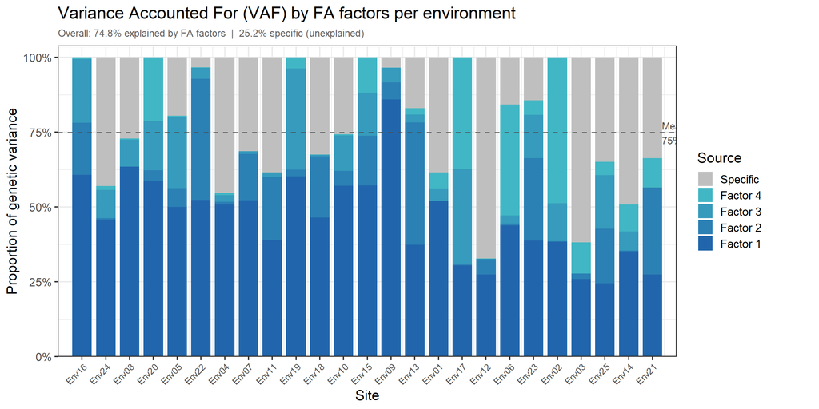

```r
fas2 <- faSummary(m2_fa4, term = "fa(Site, 4):Variety")
plot_faSummary(fas2, type = "VAF")
```

### FAST: Global OP vs Stability

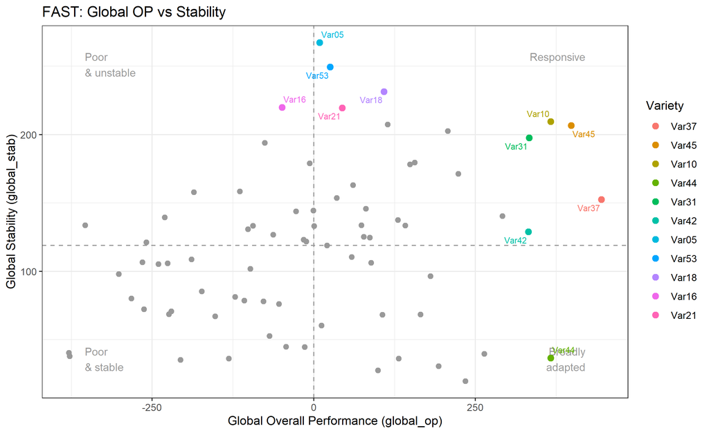

```r
plot_fastIC(res2, type = "fast", n_highlight = 6L)
```

### FA biplot

With `ic.num = 3`, each iClass is defined by the sign pattern of the first **three** loadings — up to $2^3 = 8$ potential classes. The default biplot shows Factors 1 & 2 only, so environments whose iClass differs solely in the sign of Factor 3 will overlap in this view. A second biplot using `biplot_factors = c(1L, 3L)` reveals the Factor 3 separation.

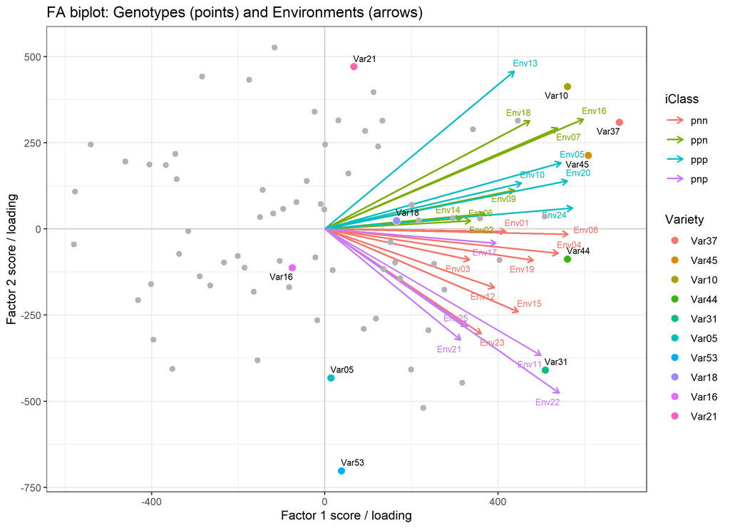

```r
plot_fastIC(res2, type = "biplot", n_highlight = 5L)
```

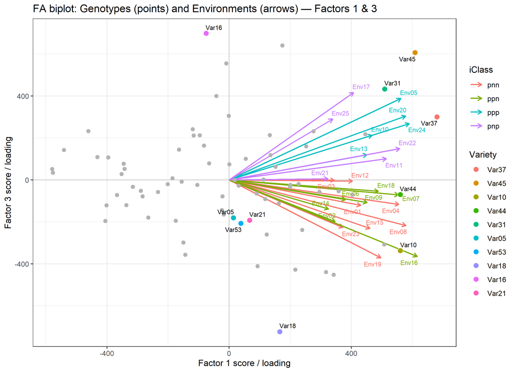

```r
plot_fastIC(res2, type = "biplot", n_highlight = 5L,
            biplot_factors = c(1L, 3L))
```

### CVE heatmap

With four iClasses the CVE heatmap is faceted into four columns, each grouping the sites that share the same three-factor loading sign pattern. The within-class rank ordering of varieties often differs strikingly from the global ranking, which motivates the iClass approach.

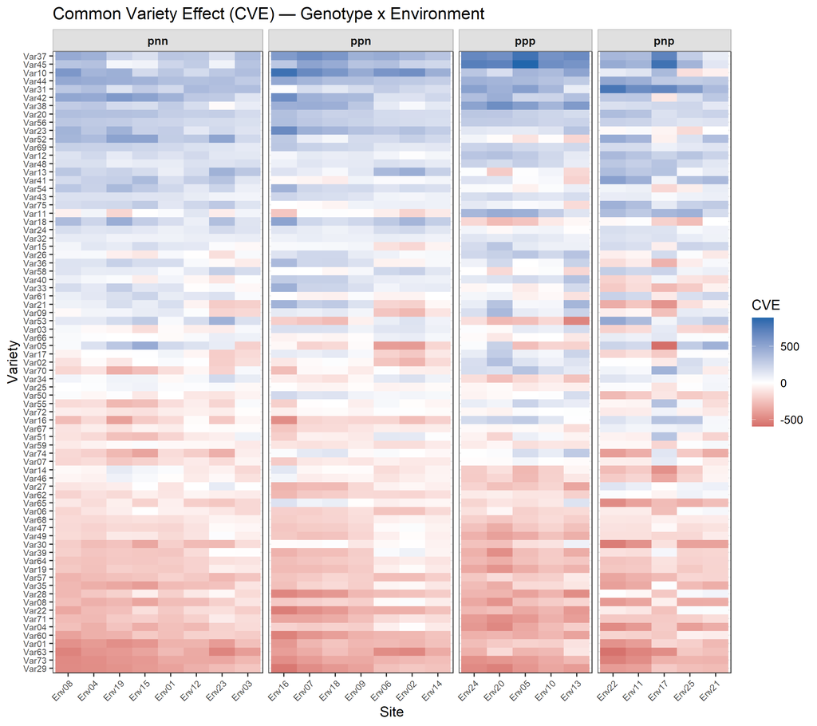

```r
plot_fastIC(res2, type = "CVE")
```

### iClass OP vs RMSD

Faceted across all iClasses, this plot highlights that the within-class RMSD for most varieties is considerably smaller than `global_stab` — evidence that the crossover GEI captured by the first three factors has been successfully isolated into the class structure.

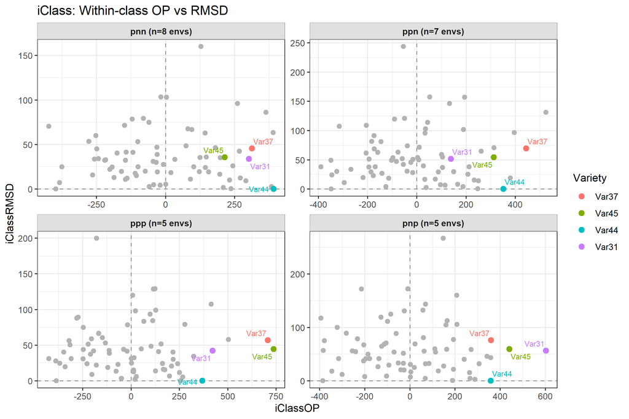

```r
plot_fastIC(res2, type = "iclass", n_highlight = 4L)
```

### Lower-triangular iClassOP pairs plot

With four iClasses the `"OP.pairs"` plot becomes a $3 \times 3$ lower-triangular matrix of pairwise iClassOP scatters — one panel for each combination of classes. Each panel uses the same diagonal reference line; points far from the diagonal are class specialists, while points near it perform similarly across both classes. The iClass structure is most informative when the cloud of points in each panel shows clear deviation from the diagonal in a consistent direction.

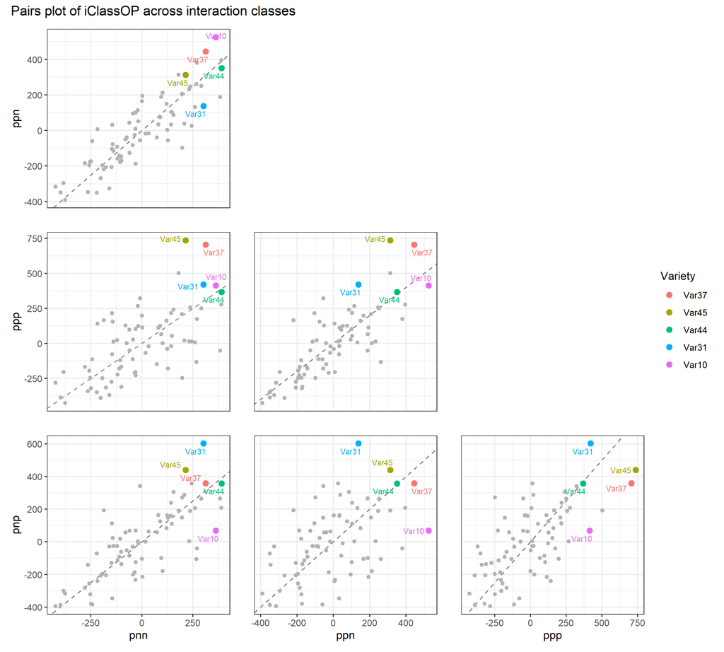

```r
plot_fastIC(res2, type = "OP.pairs", n_highlight = 5L)
```

### Variety trajectory

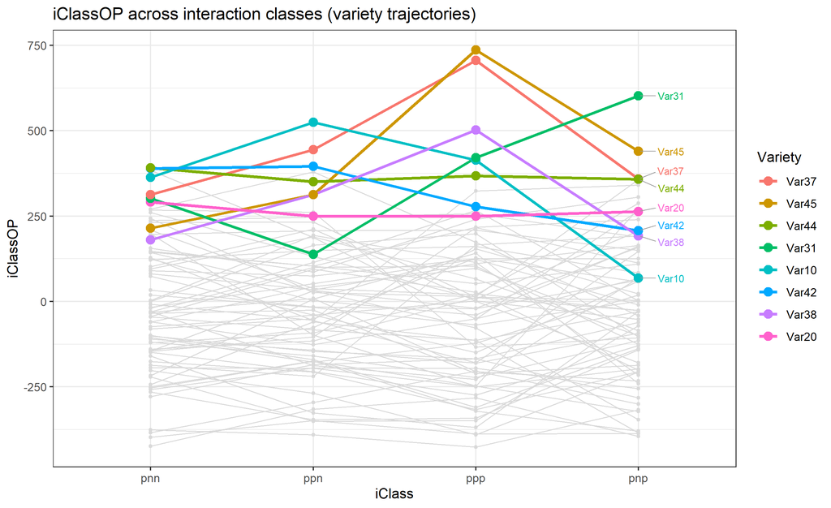

```r
plot_fastIC(res2, type = "OP.variety", n_highlight = 8L)
```

## Summary

### `fastIC()` arguments

| Argument | Default | Description |
| --- | --- | --- |
| `model` | — | Fitted ASReml-R V4 model object containing an FA random term |
| `term` | `"fa(Site, 4):Genotype"` | Full random-effect interaction string, e.g. `"fa(Env, 3):Variety"`. Supports `vm(...)` or `ide(...)` wrappers on the variety factor for relationship-aware models. |
| `ic.num` | `2L` | Number of factors used to form iClasses ($1 \le \texttt{ic.num} \le k - 1$); the kth factor is reserved for `iClassRMSD`. |
| `...` |  | Additional arguments forwarded to `faSummary()` |

### `plot_fastIC()` types

[output not shown]

All types support `highlight = "default" | character | NULL` and `return_data = TRUE` returning `list($plot, $data)`. The `biplot_factors` argument (default `c(1L, 2L)`) selects which two FA factor axes to display in the biplot.

## References

Smith, A.B. & Cullis, B.R. (2018). Plant breeding selection tools built on factor analytic mixed models for multi-environment trial data. *Euphytica*, **214**, 143.

Smith, A.B., Norman, A., Kuchel, H. & Cullis, B.R. (2021). Plant variety selection using interaction classes derived from factor analytic linear mixed models: models with independent variety effects. *Frontiers in Plant Science*, **12**, 737462.